# Accessing GBIF data using a Web API

## Accessing GBIF data using a Web API

### STEP 0 - Load the libraries

```r
library(httr2)       # -> for HTTP requests
library(jsonlite)    # -> for handling JSON content
library(sf)          # -> for spatial data manipulation
library(dplyr)       # -> for data manipulation
library(ggplot2)     # -> for plotting
library(rnaturalearth) # -> for spatial data access
```

### STEP 1 - Import the data

```r
# STEP 1 - Make request to the GBIF API
search_params <- list(
  scientificName = "Bubo scandiacus",
  stateProvince = "Quebec",
  eventDate = "2010-01-01,2021-12-31",
  limit = 10
)

url <- "https://api.gbif.org/v1/occurrence/search"

response <- httr2::request(url) |>
  httr2::req_url_query(!!!search_params) |>
  httr2::req_perform()

# Print the response content
print(response)
```

[output not shown]

### STEP 2 - Data manipulation and cleaning

The response from the GBIF API is in JSON format. We can use the `jsonlite` package to parse the JSON content into R objects. The `fromJSON()` function reads the JSON content and returns an R object. The `simplifyDataFrame` parameter is used to convert nested lists to data frames.

It is very common that APIs returns multiple level of nested lists, making the data difficult to work with. This workflow simplifies the data structure by converting nested lists to data frames.

We use the package `sf` to work with spatial data in R and project the coordinates to a coordinate reference system (CRS) that is suitable for plotting over Quebec (e.g., EPSG:32198).

```r
# Parse the response content as an R friendly object
data <- httr2::resp_body_string(response) |>
  jsonlite::fromJSON(simplifyDataFrame = TRUE)

data <- data$results |> sf::st_as_sf(
        coords = c("decimalLongitude", "decimalLatitude"), crs = 4326) |>
    sf::st_transform(32198)

# Data summary
print(data)
```

```
#> Simple feature collection with 10 features and 73 fields
#> Geometry type: POINT
#> Dimension:     XY
#> Bounding box:  xmin: -446241.8 ymin: 166435.9 xmax: -116038.9 ymax: 378482.5
#> Projected CRS: NAD83 / Quebec Lambert
#>           key                           datasetKey                     publishingOrgKey                      installationKey
#> 1  3583551173 4fa7b334-ce0d-4e88-aaae-2e0c138d049e e2e717bf-551a-4917-bdc9-4fa0f342c530 7182d304-b0a2-404b-baba-2086a325c221
#> 2  3563003883 4fa7b334-ce0d-4e88-aaae-2e0c138d049e e2e717bf-551a-4917-bdc9-4fa0f342c530 7182d304-b0a2-404b-baba-2086a325c221
#> 3  3573525980 4fa7b334-ce0d-4e88-aaae-2e0c138d049e e2e717bf-551a-4917-bdc9-4fa0f342c530 7182d304-b0a2-404b-baba-2086a325c221
#> 4  3504244893 4fa7b334-ce0d-4e88-aaae-2e0c138d049e e2e717bf-551a-4917-bdc9-4fa0f342c530 7182d304-b0a2-404b-baba-2086a325c221
#> 5  3553400984 4fa7b334-ce0d-4e88-aaae-2e0c138d049e e2e717bf-551a-4917-bdc9-4fa0f342c530 7182d304-b0a2-404b-baba-2086a325c221
#> 6  3631749066 4fa7b334-ce0d-4e88-aaae-2e0c138d049e e2e717bf-551a-4917-bdc9-4fa0f342c530 7182d304-b0a2-404b-baba-2086a325c221
#> 7  3572096204 4fa7b334-ce0d-4e88-aaae-2e0c138d049e e2e717bf-551a-4917-bdc9-4fa0f342c530 7182d304-b0a2-404b-baba-2086a325c221
#> 8  3582022084 4fa7b334-ce0d-4e88-aaae-2e0c138d049e e2e717bf-551a-4917-bdc9-4fa0f342c530 7182d304-b0a2-404b-baba-2086a325c221
#> 9  3585261095 4fa7b334-ce0d-4e88-aaae-2e0c138d049e e2e717bf-551a-4917-bdc9-4fa0f342c530 7182d304-b0a2-404b-baba-2086a325c221
```

[output cut: 100 more lines]

### STEP 3 - Visualize the data

The `ggplot2` package is a powerful tool for creating visualizations in R. The `geom_sf()` function from the `ggplot2` package can be used to plot spatial data stored in an `sf` object.

The `rnaturalearth` package provides easy access to geometry for cultural and physical features of the world. We can use the `ne_states()` function to get the geometry of the provinces of Canada and plot the occurrence data over the province of Quebec.

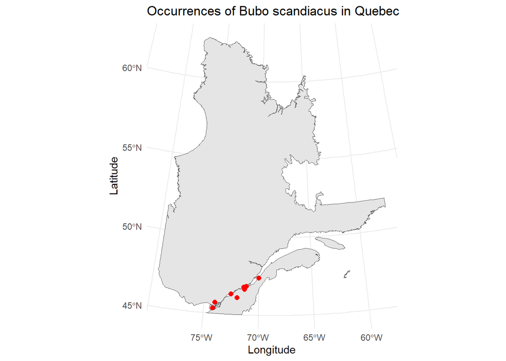

```r
# Get the province of Quebec
quebec <- ne_states(country = "canada", returnclass = "sf") %>%
  filter(name_en == "Quebec") |>
    sf::st_transform(32198)

# Plot the data
ggplot() +
  geom_sf(data = quebec) +
  geom_sf(data = data, color = "red", size = 2) +
  theme_minimal() +
  labs(title = "Occurrences of Bubo scandiacus in Quebec",
       x = "Longitude", y = "Latitude")
```